Data Analysis · MBAA 531

# Decoding Global Compensation

By **Jie Zhang** · Dataset: Global Compensation Data

## The Data

This dataset measures global compensation factors, including salary variations, professional experience levels, and remote work arrangements. The unit of observation is an individual worker, with the dataset encompassing exactly 23,876 records across 10 distinct variables. Understanding these metrics is crucial for identifying how remote flexibility and career tenure impact earning potential in today’s rapidly evolving global labor market.

## The Central Finding

To understand the true return on professional tenure, we created a derived variable: Salary per Year of Experience. By dividing the total annual salary by years of experience (and slightly adjusting entry-level roles to prevent mathematical errors), we can isolate the financial value of a single year of industry tenure.

$14,764 Median Salary per Year of Experience

This figure represents the median annual value of one year of experience across the dataset. We utilize the median, rather than the average, to prevent extreme salary outliers from skewing the results. In practical terms, it establishes a global benchmark for how much earning power a professional theoretically gains for each year spent in the workforce.

## A Closer Look

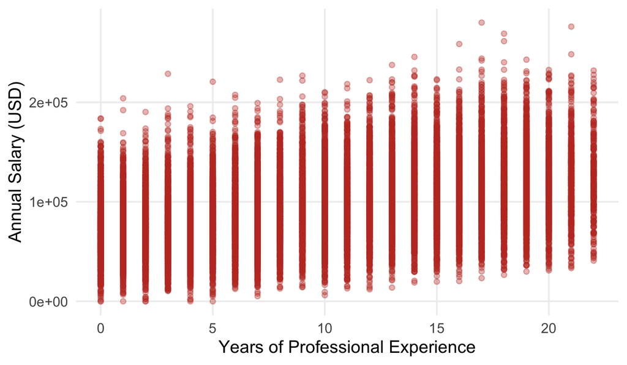

While there is a clear upward trajectory, the significant vertical spread at higher experience levels suggests that tenure alone does not guarantee top-tier compensation. This indicates that other structural factors must be at play to explain the highest earners.

## Across Groups

To understand the variance observed in our initial scatter plot, we segment the compensation data by professional experience tiers. The ridge chart below visualizes the salary density distributions across these distinct career stages, revealing exactly how earning power shifts as professionals move from entry-level to senior roles.

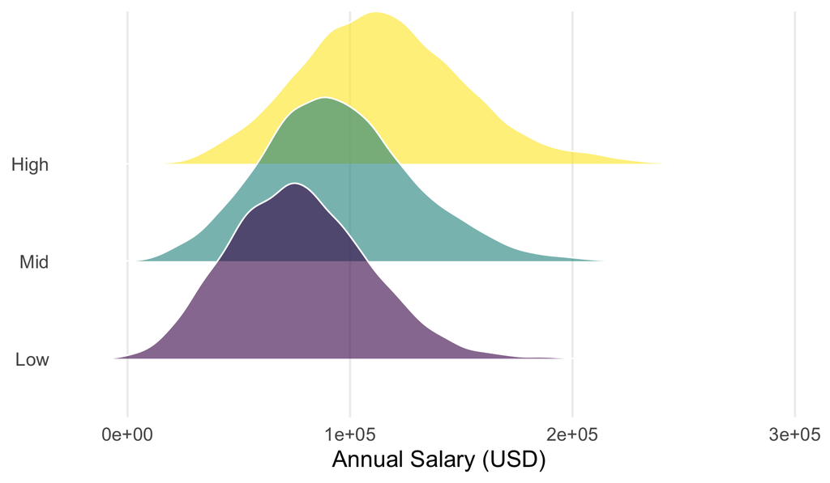

Chart 2: Salary density distributions (USD) categorized by experience tiers, highlighting the progressive shifts and widening spread in compensation.

## What This Means

The ridge distributions further clarify this structural shift. Moving into senior experience tiers elevates the entire earning potential, but it also flattens and stretches the salary curve significantly. For decision-makers and HR strategists, the takeaway is critical: base salary scales linearly with time, but premium compensation is awarded for factors beyond mere tenure—most likely specialized skill sets, leadership capabilities, or strategic market value.

Ultimately, organizations must rethink how they structure senior compensation packages. However, a critical question remains unanswered by this dataset: which specific capabilities command that massive financial premium at the senior level? Is the highest variance driven by niche technical expertise, or by executive management responsibilities?